# TP 2 : Simulation de lois de probabilités

# Lois discrètes

## Loi uniforme discrète

Soit $X$ une variable aléatoire distribuées selon une loi uniforme discrète sur $\{1,\ldots,n\}$.

La distribution est définie comme suit :
$$\forall k\in \{1,\ldots,n\}, \, p(X=k)=\frac 1n$$

En R,

```r
n<-30
ech<-sample(1:10,n,replace=T)
table(ech)/n
```

```
## ech
##          1          2          3          4          5          6
## 0.06666667 0.06666667 0.10000000 0.16666667 0.16666667 0.10000000
##          7          8          9         10
## 0.06666667 0.03333333 0.13333333 0.10000000
```

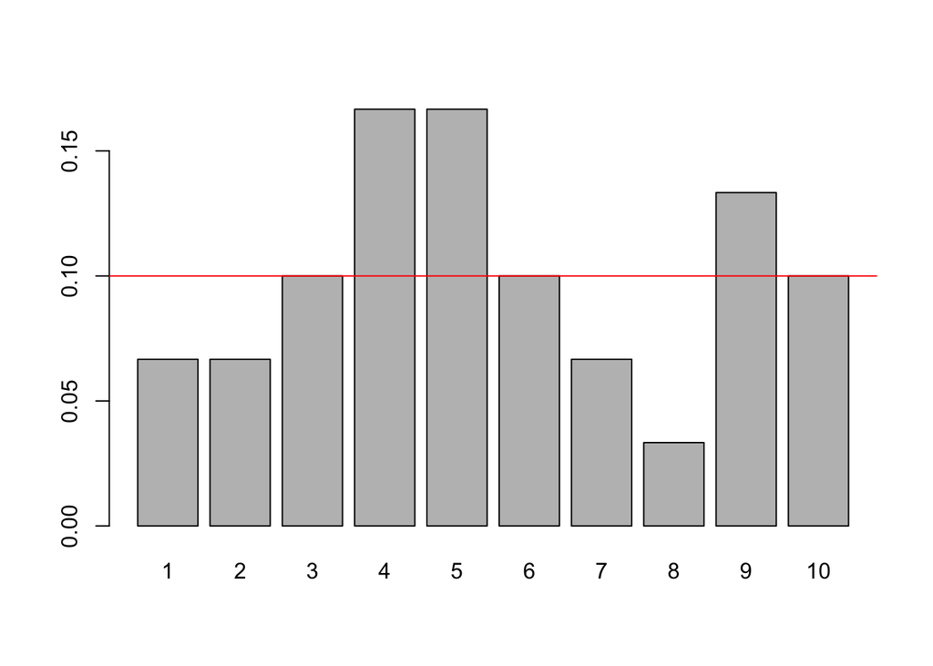

```r
barplot(table(ech)/n)
abline(h=1/10,col="red")
```

## Loi de Bernoulli

Cette loi est notée $\mathcal B(p)$. On dit que $X\leadsto \mathcal B(p)$ si et seulement si $X$ est une variable binaire telle que (on parle de loi succès/échec) :
$$P(X=1)=p$$
et
$$P(X=0)=1-p=q$$

C’est un cas particulier de la loi binomiale avec $n=1$.

On peut vérifier facilement par le calcul que $\mathbb E[X]=p$ et $\mathbb V[X] = pq = p(1-p)$.

```r
n<- 30  # taille de l'échantillon
p<-0.3   # paramètre de la loi de Bernoulli
esp<-p
var<-p*(1-p)
ech<-rbinom(n,size = 1,prob = p) # size = 1 correspond à la loi de Bernoulli
table(ech)/n
```

```
## ech
##   0   1
## 0.6 0.4
```

```r
paste("La moyenne de l'échantillon est ",mean(ech),", sachant que l'espérance vaut",esp)
```

```
## [1] "La moyenne de l'échantillon est  0.4 , sachant que l'espérance vaut 0.3"
```

```r
paste("La variance de l'échantillon est ",round(var(ech),2),", sachant que la variance de la loi vaut",p*(1-p))
```

```
## [1] "La variance de l'échantillon est  0.25 , sachant que la variance de la loi vaut 0.21"
```

## Loi binomiale

On dit que $X$ suit une loi binomiale, notée $\mathcal B(n,p)$.

On dit que cette loi est la somme de lois de Bernoulli indépendantes et de même paramètre, ce qui revient à compter le nombre de succès (nombre de $1$) parmi les $n$ expériences. Cela revient donc à faire $n$ fois une expérience (qui a une probabilité $p$ de réussir) identique, de façon indépendante. $X$ représente donc le nombre de succès.

Pour résumer, soit $Y_i\leadsto \mathcal B(p)$ pour $i=1,\ldots,n$, où les $Y_i$ sont indépendants. On note
$$X = \sum_{i=1}^n Y_i \leadsto \mathcal B(n,p)$$

Les valeurs possibles pour la variable $X$ sont $\{0,\ldots,n\}$ et
$$\forall k\in\{0,\ldots,n\},\, p_k=p(X=k)=C_n^k p^k (1-p)^{n-k}$$

On peut remarquer que la somme des probabilités est bien égale à 1 grace à la formule du binôme de Newton :
$$(a+b)^n = \sum_{k=0}^n C_n^k a^kb^{n-k}$$
En prenant $a=p$ et $b=q=1-p$ on trouve :
$$\sum_{k=0}^n p_k= \sum_{k=0}^nC_n^k p^k (1-p)^{n-k} = (p+1-p)^n=1^n=1$$

L’espérance de cette loi est (grâce à la **linéarité de l’espérance**)
$$\mathbb E[X] = \sum_{i=1}^n \mathbb E[Y_i] = \sum_{i=1}^n p = np$$
La variance de cette loi est
$$\mathbb V[X] = \sum_{i=1}^n \mathbb V[Y_i] = \sum_{i=1}^n p(1-p) = np(1-p)$$
Attention, dans cette dernière formule, il ne faut pas croire que nous utilisons la linéarité de la variance ! **La variance n’est pas linéaire**. Pour rappel :
$$\mathbb V[aX] = a^2 \mathbb V[X]$$
et
$$\mathbb V[X_1+X_2] = \mathbb V[X_1] + \mathbb V[X_2] + 2*\mathrm{cov}(X_1,X_2)$$
Enfin, si $X_1$ et $X_2$ sont indépendantes, alors
$$\mathrm{cov}(X_1,X_2)=0$$

En R, cela donne

```r
N<- 100 # taille de l'échantillon
n<- 10L  # premier paramètre de la loi
p<- 0.8 # deuxième paramètre de la loi

ech<-rbinom(N,n,p)
table(ech)/N
```

```
## ech
##    3    5    6    7    8    9   10
## 0.01 0.04 0.01 0.21 0.41 0.26 0.06
```

```r
dbinom(x=0:n,size = n,prob = p)
```

```
##  [1] 0.0000001024 0.0000040960 0.0000737280 0.0007864320 0.0055050240
##  [6] 0.0264241152 0.0880803840 0.2013265920 0.3019898880 0.2684354560
## [11] 0.1073741824
```

**Faites varier les différents paramètres de la loi binomiale et étudier ses proriétés.**

## Loi Géométrique

On dit que $X$ suit une loi géométrique, notée $\mathcal G(p)$ avec $0<p<1$.

Cette loi correspond au shéma suivant. On répète, de façon indépendante, une même expérience (qui a une probabilité $p$ de réussite et une probabilité $q=1-p$ d’échec) et on note $X$ le rang du premier succès.

Les valeurs prises par $X$ sont donc $X(\Omega)=\mathbb N^\star$ et les probabilités associées sont :
$$\forall k\in\mathbb N^\star,\, p_k=P(X=k) = (1-p)^{k-1}p = q^{k-1}p$$
On remarque que ces probabilités $p_k$ définissent une suite géométrique de raison $q$.

Pour rappel, si $0<q<1$ alors
$$\sum_{k=n_0}^n q^k = q^{n_0}\dfrac{1-q^{n-n_0+1}}{1-q}$$
et donc par passage à la limite
$$\sum_{k=n_0}^{+\infty} q^k = \dfrac{q^{n_0}}{1-q}$$
En appliquant cette formule pour calculer la somme des probabilités, on trouve

$$\sum_{k=1}^{+\infty} p_k = \sum_{k=1}^{+\infty} q^{k-1}p=p\sum_{k=0}^{+\infty}q^k=p/(1-q) = 1$$

L’espérance de cette loi est :
$$\mathbb E[X] = \sum_{k=1}^{+\infty} kp_k = p\sum_{k=1}^{+\infty}kq^{k-1} = p/(1-q)^2 = 1/p$$
Le moment d’ordre 2 de cette loi est :
$$\mathbb E[X^2] = \sum_{k=1}^{+\infty} k^2p_k = p\sum_{k=1}^{+\infty}k(k-1+1)q^{k-1} = pq\sum_{k=1}^{+\infty} k(k-1)q^{k-2} + p\sum_{k=1}^{+\infty}kq^{k-1} = pq\dfrac{2}{(1-q)^3}+1/p = \dfrac{2(1-p)+p}{p^2}= \dfrac{1+q}{p^2}$$
La variance vaut

$$\mathbb V[X] = \mathbb E[X^2] - \mathbb E[X]^2 = \dfrac{1+q}{p^2}-\dfrac{1}{p^2}=\dfrac{q}{p^2}$$

En R, il faut faire attention car il y a un décalage d’une unité. La définition dans R pour une loi géométrique est le nombre d’échecs avant la première réussite. Ainsi, les valeurs prises pour cette variable sont dans $\mathbb N$ et non pas $\mathbb N^\star$.

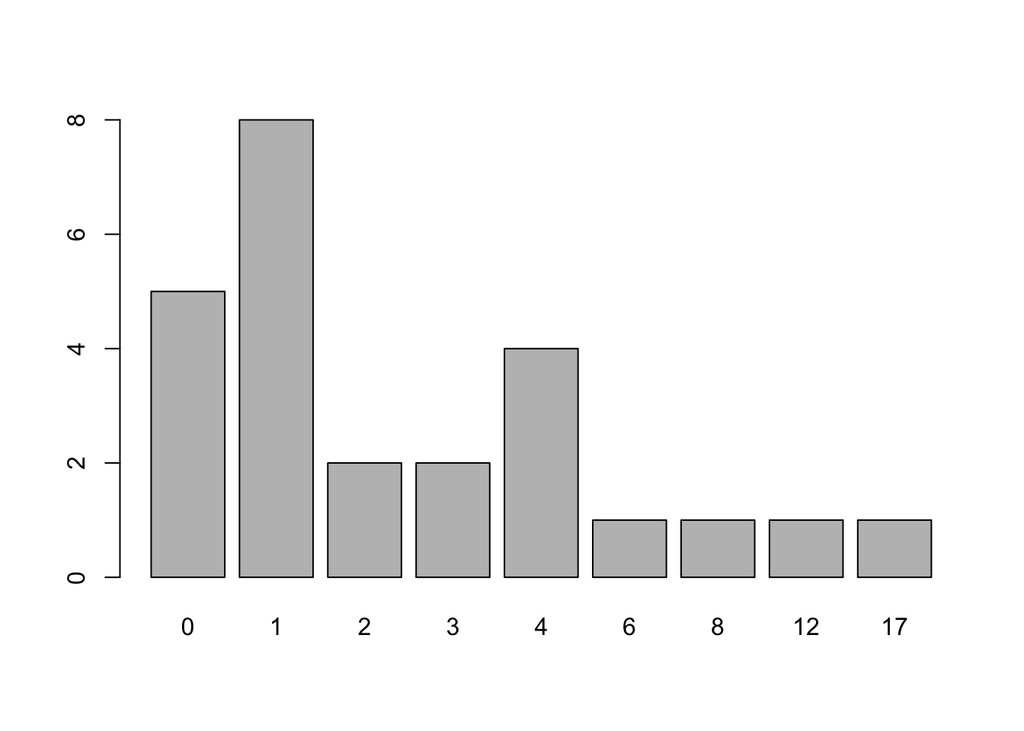

```r
n <- 25 # taille de l'échantillon
p <- 0.3 # paramètre de la loi
ech<-rgeom(n,p) # simulation de la loi
barplot(table(ech))
```

**Redéfinir une nouvelle variable ou une nouvelle fonction qui correspond à notre paramétrisation de la loi géométrique**

## Loi de Poisson

On dit que $X$ suit une loi de Poisson, notée $\mathcal P(\lambda)$ avec $\lambda>0$.

On peut voir cette loi comme la loi des événements rares. Cette loi est une approximation de la loi binomiale, $\mathcal B(n,p)$ lorsque $n$ est grand et $p$ petit (i.e. pour des événements rares). On pose alors $\lambda=np$. En pratique, on dit que cette approximation est bonne dès que $n>20$ et $p\leq 0.1$ et $np\leq 5$.

**A l’aide de simulation, vérifier que la loi binomiale peut être approchée par la loi de poisson.**

Les valeurs possibles pour $X$ sont dans $\mathbb N$ et les probabilités associées :
$$\forall k\in \mathbb N,\, p_k=P(X=k)=e^{-\lambda}\dfrac{\lambda^k}{k!}$$
On pourra vérifier (grâce à la définition de l’exponentielle $e^x=\displaystyle\sum_{k=0}^{+\infty}\dfrac{x^k}{k!}$) que
$$\sum_{k=0}^{+\infty} p_k = 1$$

L’espérance d’une loi de Poisson de paramètre $\lambda$ est :
$$\mathbb E[X] = \sum_{k=0}^{+\infty}kp_k = \sum_{k=1}^{+\infty}k p_k =\lambda e^{-\lambda}\sum_{k=1}^{+\infty}\dfrac{\lambda^{k-1}}{(k-1)!}=\lambda$$
Le moment d’ordre 2 vaut
$$\mathbb E[X^2] = \sum_{k=0}^{+\infty}k^2p_k = \sum_{k=1}^{+\infty}k^2 p_k =\lambda e^{-\lambda}\sum_{k=1}^{+\infty}(k-1+1)\dfrac{\lambda^{k-1}}{(k-1)!}=\lambda^2 e^{-\lambda}\sum_{k=2}^{+\infty}\dfrac{\lambda^{k-2}}{(k-2)!}+\lambda e^{-\lambda}\sum_{k=1}^{+\infty}\dfrac{\lambda^{k-1}}{(k-1)!}=\lambda^2+\lambda$$
et donc la variance est égale à
$$\mathbb V[X] = \mathbb E[X^2] - \mathbb E[X]^2 = \lambda^2+\lambda - \lambda^2 = \lambda$$

En R, cela donne

```r
lambda <- 3 # paramètre de la loi de Poisson
n <- 25 # taille de l'échantillon
ech <- rpois(n,lambda) # simulation de la loi de Poisson
mean(ech)
```

```
## [1] 3.4
```

```r
var(ech)
```

```
## [1] 3.166667
```

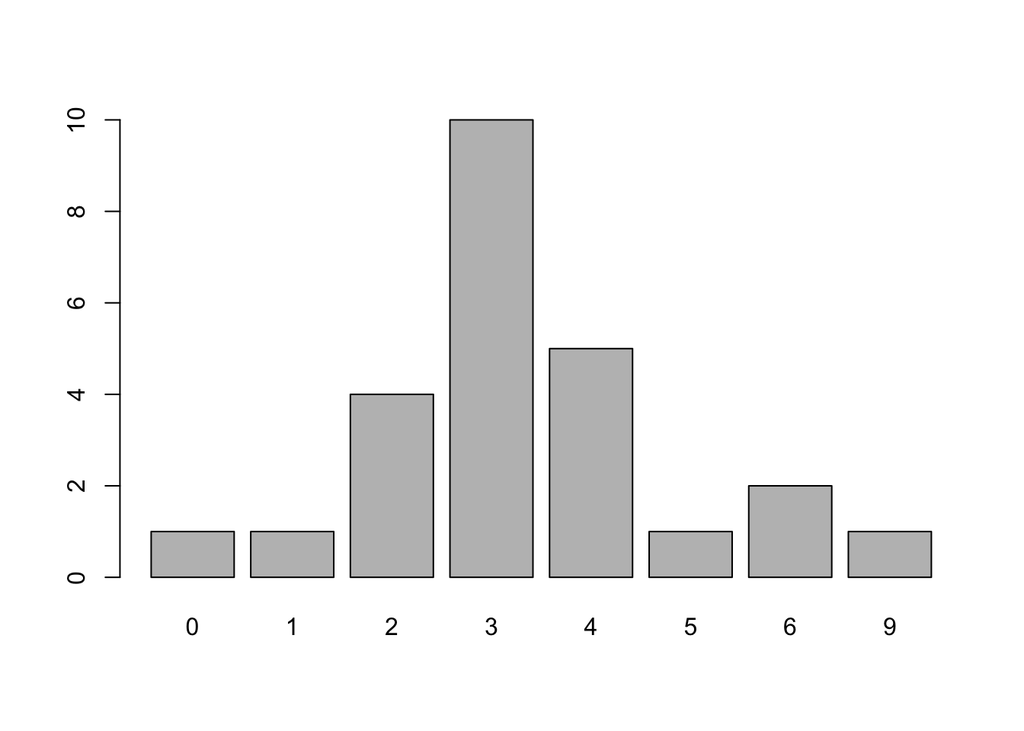

```r
barplot(table(ech))
```

**Simulez différentes lois de Poisson en faisant varier $\lambda$ ainsi que la taille de l’échantillon.**

**Pour toutes ces lois, comparer la fonction de répartition empirique avec la théorique.**

# Lois continues

## Introduction

Lisez la partie du cours relative aux lois continues.

## Loi uniforme sur $[0,1]$, notée $U_{[0,1]}$

On dit que $X$ suit une loi uniforme sur $[0,1]$ ssi sa fonction densité est :
$$\forall x\in\mathbb R,\,f(x)= \left \lbrace \begin{array}{cl}
1 & \text{si } x \in [0,1] \\
0 & \text {sinon}
\end{array}
\right.$$

La fonction de répartition d’une loi uniforme sur $[0,1]$ est
$$\forall x\in\mathbb R,\, F(x)=\int_{-\infty}^x f(t)\,dt = \left \lbrace
\begin{array}{cl}
0 & \text{si } x<0 \\
x & \text{si } x \in [0,1] \\
1 & \text{si } x > 1
\end{array}
\right.$$

L’espérance de la loi uniforme $U_{[0,1]}$ est
$$\mathbb E[X] = \int_{-\infty}^{+\infty} xf(x)\,dx = \int_{0}^{1} x\,dx = \left[ \dfrac{x^2}{2}\right]_0^1= \dfrac{1}{2}$$

Le moment d’ordre 2 est
$$\mathbb E[X^2] = \int_{-\infty}^{+\infty} x^2f(x)\,dx = \int_{0}^{1} x^2\,dx=\left[ \dfrac{x^3}{3}\right]_0^1= \dfrac{1}{3},$$
et donc la variance vaut
$$\mathbb V[X] = \mathbb E[X^2]- \mathbb E[X]^2 = 1/3 - 1/4 = 1/12.$$

```r
n <- 30
ech <- runif(n)
mean(ech)
```

```
## [1] 0.4322295
```

```r
var(ech)
```

```
## [1] 0.05778539
```

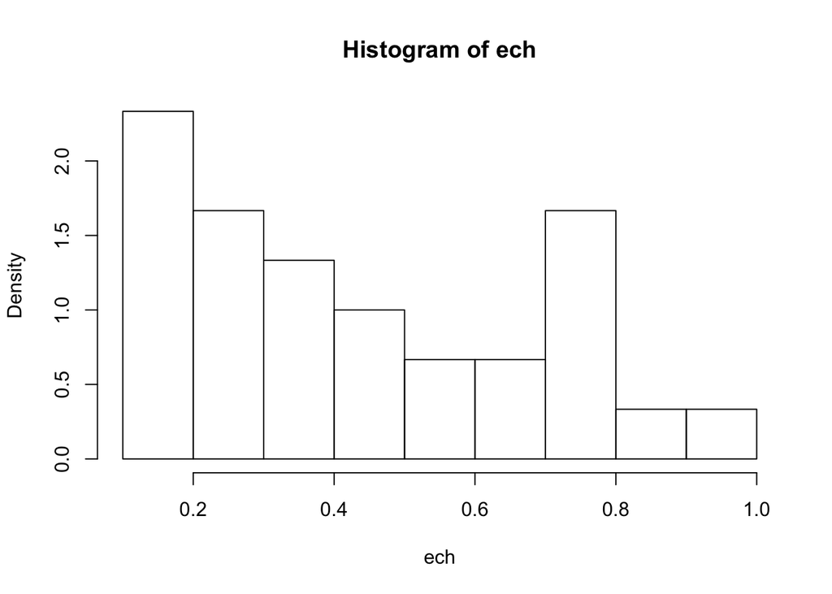

```r
hist(ech,freq=F)
```

## Loi uniforme sur $[a,b]$, notée $U_{[a,b]}$, avec ($a<b$)

On dit que $X\leadsto U_{[a,b]}$ ssi sa fonction densité est
$$\forall x\in\mathbb R,\,f(x)= \left \lbrace \begin{array}{cl}
\dfrac{1}{b-a} & \text{si } x \in [a,b] \\
0 & \text {sinon}
\end{array}
\right.$$

La fonction de répartition d’une loi uniforme sur $[a,b]$ est
$$\forall x\in\mathbb R,\, F(x)=\int_{-\infty}^x f(t)\,dt = \left \lbrace
\begin{array}{cl}
0 & \text{si } x<a \\
\dfrac{x-a}{b-a} & \text{si } x \in [a,b] \\
1 & \text{si } x > b
\end{array}
\right.$$

L’espérance vaut
$$\mathbb E[X] = \int_{-\infty}^{+\infty} xf(x)\,dx = \int_{a}^{b} \dfrac{x}{b-a}\,dx = \dfrac{1}{b-a} \left[ \dfrac{x^2}{2}\right]_a^b= \dfrac{b^2-a^2}{2(b-a)} = \dfrac{a+b}2$$

Le moment d’ordre 2 est
$$\mathbb E[X^2] = \int_{-\infty}^{+\infty} x^2f(x)\,dx = \int_{a}^{b} \dfrac{x^2}{b-a}\,dx=\dfrac{1}{b-a}\left[ \dfrac{x^3}{3}\right]_0^1= \dfrac{b^3-a^3}{3(b-a)} = \dfrac{a^2 + ab+b^2}{3},$$
et donc la variance vaut
$$\mathbb V[X] = \mathbb E[X^2] - \mathbb E[X]^2 = \dfrac{a^2 + ab+b^2}{3} - \dfrac{a^2+2ab+b^2}{4} = \dfrac{a^2-2ab+b^2}{12} = \dfrac{(b-a)^2}{12}$$

**Théorème : Si $\mathbf{X\leadsto U_{[0,1]}}$ alors $\mathbf{Y=(b-a)X+a \leadsto U_{[a,b]}}$.**

En R, il n’est pas utile de connaître ce théorème car la fonction *runif* permet de passer les bornes $a$ et $b$ en arguments.

```r
n<-30
ech<-runif(n,2,5) # simulation d'un échantillon d'une loi uniforme sur [2,5]
mean(ech)
```

```
## [1] 3.495684
```

```r
var(ech)
```

```
## [1] 0.7500752
```

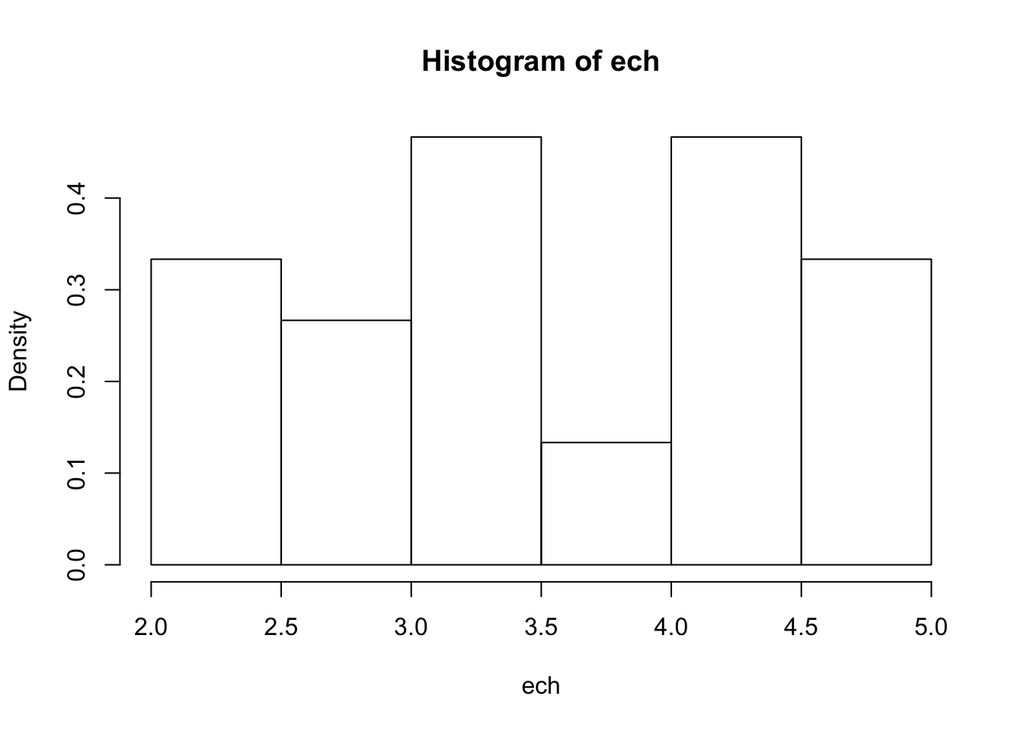

```r
hist(ech,freq=F)
```

## Loi Normale centrée réduite, notée $\mathcal N(0,1)$

Si $X\leadsto \mathcal N(0,1)$ alors la fonction densité de $X$ est
$$\forall x\in\mathbb R,\, f(x)= \dfrac{1}{\sqrt{2\pi}}e^{-\frac{x^2}{2}}$$

Le premier paramètre de la loi normale est l’espérance de la loi et le second correspond à la variance de la loi. On peut remarquer que cette fonction est paire, i.e. $\forall x\in\mathbb R,\,f(-x)=f(x)$, ce qui implique une symétrie par rapport à l’axe des ordonnées.

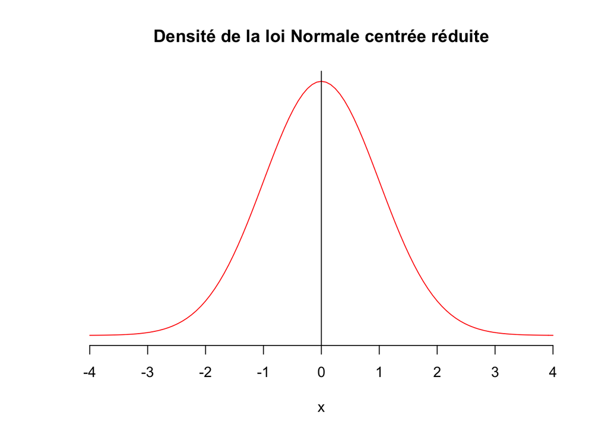

```r
curve(dnorm,from = -4,to = 4,col="red",main="Densité de la loi Normale centrée réduite",ylab="",axes=F)
axis(1,xaxp=c(-4,4,8))
axis(2,pos=0,c(-1,1))
```

On peut également remarquer que la courbe s’approche très rapidement de l’axe des abscisses dès lors que l’on séloigne de l’espérance (ici 0).

```r
n<-100
ech<-rnorm(n) # simulation d'une loi normale centrée réduite
mean(ech)
```

```
## [1] -0.02140691
```

```r
var(ech)
```

```
## [1] 0.9093207
```

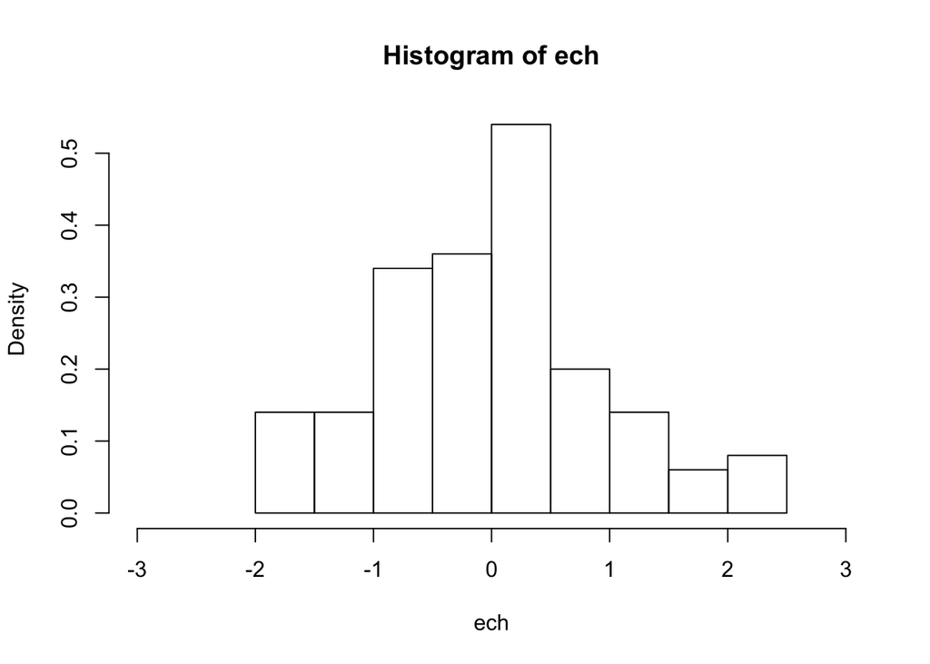

```r
hist(ech,freq=F,breaks=10,xlim = c(-3,3))
```

**Vérifier de plusieurs manières que**
$$\mathbf{\int_{-\infty}^{+\infty}e^{-\dfrac{x^2}{2}}\,dx=\sqrt{2\pi}}.$$

L’espérance de la loi normale centrée réduite vaut
$$\mathbb E[X] = \int_{-\infty}^{+\infty}xf(x)\,dx = \dfrac{1}{\sqrt{2\pi}}\int_{-\infty}^{+\infty}xe^{-\dfrac{x^2}{2}}\,dx =0$$

Le moment d’ordre 2 (qui est aussi la variance car l’espérance est nulle) se calcule par une intégration par parties
$$\mathbb V[X]=\mathbb E[X^2] = \int_{-\infty}^{+\infty}x^2f(x)\,dx = \dfrac{1}{\sqrt{2\pi}}\int_{-\infty}^{+\infty}x^2e^{-\dfrac{x^2}{2}}\,dx =\dfrac{2}{\sqrt{2\pi}}\int_{0}^{+\infty}x^2e^{-\dfrac{x^2}{2}}\,dx$$
Or
$$\int_{0}^{t}x^2e^{-\dfrac{x^2}{2}}\,dx = \left[ -xe^{-\frac{x^2}{2}}\right]_0^t+\int_0^te^{-\frac{x^2}{2}}\,dx \underset{t \to \infty}{\longrightarrow} \int_0^{+\infty}e^{-\frac{x^2}{2}}\,dx = \sqrt{\frac{\pi}{2}}$$
et donc
$$\mathbb V[X] = 1$$

## Loi Normale $\mathcal N(\mu,\sigma^2)$

On dit que $X\leadsto\mathcal N(\mu,\sigma^2)$ si sa fonction densité est :
$$\forall x\in\mathbb R,\, f(x)= \dfrac{1}{\sigma\sqrt{2\pi}}e^{-\frac{(x-\mu)^2}{2\sigma^2}}$$
On pourra vérifier que l’intégrale de cette fonction sur $\mathbb R$ vaut bien 1. $\mu$ représente l’espérance de la loi et $\sigma^2$ la variance.

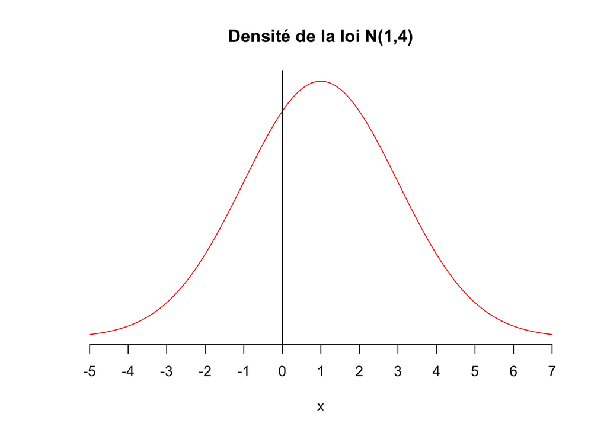

```r
curve(dnorm(x,mean=1,sd=2),from = -5,to = 7,col="red",main="Densité de la loi N(1,4)",axes=F,ylab="") # Attention, on rentre l'écart-type et non la variance !!!
axis(1,xaxp = c(-5,7,12))
axis(2,pos=0,c(-1,1))
```

Que remarquez-vous ?

**Théorème : Si** $\mathbf{X\leadsto\mathcal N(\mu,\sigma^2)}$ **alors** $\mathbf{\dfrac{X-\mu}\sigma\leadsto\mathcal N(0,1)}$

Ce théorème est extrêmement important car il dit qu’on est toujours capable de se ramener à une loi normale centrée réduite (encore faut-il connaître l’espérance et la variance de la loi).

**Mettre en oeuvre un programme permettant de vérifier ce théorème par la simulation.**